# NYC Subway-Weather Data

## Section 0. References

scipy ttest documentation

GraphPad Man-Whitney U test Guide

statsoft.com

minitab blog on R<sup>2</sup>

## Section 1. Statistical Test

#### 1.1

I used a **Mann-Whitney U test** to analyze the NYC subway data. Specifically the `mannwhitneyu` method from the `scipy.stats` module.

The `scipy.stats` module `mannwhitneyu` method yeilds a **one-tail P value** which I then doubled to get a **two-tail P value**.

**The two-tailed null hypothesis of the Mann-Whitney U test is that** if we draw samples randomly from two distributions the probability of the first sample having a larger mean than the other is 0.5. In this case that means that the null hypothesis is that the distribution of ridership on rainy days is the same as that on non rainy days.

The standard test for significance uses a p-critical value of: **0.05**

#### 1.3

The **one-tail P value** is 2.74e-06 meaning that the **two-tail P value is 5.48e-06**. The **mean entries per hour** on rainy days is **2028.20**, and on non-rainy days it is **1845.54**.

#### 1.4

Given that the two-tail P value is considerably less that P-critical, these results strongly suggest that we reject the null hypothesis. We can say with a high degree of confidence that the distribution of the rainy-day ridership population is higher than that of the non-rainy day population.

```python
pd.DataFrame([rain.describe(), no_rain.describe()])
```

|  | count | mean | std | min | 25% | 50% | 75% | max |
| --- | --- | --- | --- | --- | --- | --- | --- | --- |
| ENTRIESn_hourly | 9585 | 2028.196035 | 3189.433373 | 0 | 295 | 939 | 2424 | 32289 |
| ENTRIESn_hourly | 33064 | 1845.539439 | 2878.770848 | 0 | 269 | 893 | 2197 | 32814 |

## Section 2. Linear Regression

#### 2.1

I used the `LinearRegression` class from `sklearn.linear_model` to compute the coefficients theta and produce prediction for ENTRIESn_hourly in my regression model.

#### 2.2

For features I used the columns `precipi`, `pressurei`, `meanpressurei`, `meantempi`. I also used the columns `UNIT`, `DATEn`, `TIMEn` as a dummy variables thinking that they could be an important features, but that it would not make sense to perform arithmetic operations on their values.

#### 2.3

I arrived at this feature set programatically after becoming unsatisfied with my intuitions. I had experimented with hypotheses such as 'people may use the subway more if there was thunder or fog, etc.' but the results didn't give me confidence that they provided real insight. Instead I decided to just try all possible four feature combinations drawn from the list `[u'hour', u'fog', u'precipi', u'pressurei', u'rain', u'tempi', u'wspdi', u'meanprecipi', u'meanpressurei', u'meantempi', u'meanwspdi']`. I tried with just the `UNIT` dummy variable and all three mentioned above. Then I selected the combination (noted in 2.2) that gave me the highest R<sup>2</sup> value.

#### 2.4

The coefficients of my non-dummy features were: `{precipi: 394.76352183, pressurei: -64.18835463, meanpressurei: -92.04017317, meantempi: -19.57046952]`.

#### 2.5

The R<sup>2</sup> value this feature set achieved in combination with the dummy variables was **0.53**.

#### 2.6

This R<sup>2</sup> isn't bad, but it also isn't great. There is definitely some predictive correlation between these features and ridership, but when used predictively, it is not likely to be very accurate. The R<sup>2</sup> value of **0.53** indicates that we have accounted for %53 of the variability. With %47 variability left unaccounted for, it is difficult to say with certainty that we have captured a strong causal relationship. As we can see from a visualization of the residual variablity, the model does not make a tight normal distribution around 0.

```python
preds = predictions(df, ['precipi', 'pressurei', 'meanpressurei', 'meantempi'])
```

[output not shown]

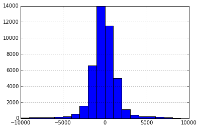

```python
plot_residuals(df, preds)
```

## Section 3 Visualization

#### 3.1

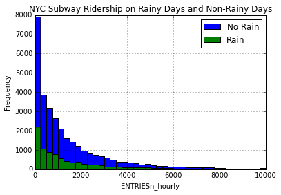

```python
plt.figure()
plt.ylabel('Frequency')
plt.xlabel('ENTRIESn_hourly')
plt.title('NYC Subway Ridership on Rainy Days and Non-Rainy Days')

no_rain = y.hist(label="No Rain", bins=40, range=[0,10000])
rain = x.hist(label="Rain", bins=40, range=[0,10000])

plt.legend()

plt.show()
```

The histogram above illustrates that the distributions are not normal. In fact they both appear to be positively skewed. Apart from that, we cannot say much else about the distributions, especially not whether they are drawn from the same population or not.

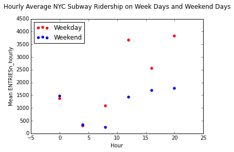

```python
plt.figure()
plt.xlabel('Hour')
plt.ylabel('Mean ENTRIESn_hourly')
plt.title('Hourly Average NYC Subway Ridership on Week Days and Weekend Days\n')

plt.scatter(weekday.keys(), weekday.values(), label="Weekday", color='red')
plt.scatter(weekend.keys(), weekend.values(), label="Weekend", color='blue')

plt.legend(loc='upper left')

plt.show()
```

It is interesting to note that given the scatterplot above, ridership on weekends seems very simialr to weekday ridership in the very late night hours. One would anticipate the differences in rush hour ridership. The plot also confirms my own suspicion that people tend more often to ride the subway on weekdays and not on weekends.

## Section 4. Conclusion

My general conclusion is that more people ride the subway when it is raining than do when it is not. Support for this conclusion comes from the results of a Mann-Whitney-U test conducted on the data which shows that there is strong reason to reject the null hypothesis, which in this case states that the distribution of ridership is the same when it is raining as when it is not. The alternative hypothesis is that one of these samples is drawn from a population with a greater mean, and having analyzed the respective means of the samples it is reasonable to conclude that it is the sample of rainy data that yields the higher of the two. Of course to say that more people ride the subway when it is raining than do when it is not is an over simplification. Based on the analysis of the linear regression exercises that I conducted, it would be more precise to say that a combination of the amount of precipitation, temperature, and barometric preasure contribute to the increase in ridership of the New York subway system. However, considering the relative weights of the features used in this analysis, it does appear that precipitation is the major contributing factor, an observation that supports the claim that more people ride the subway when it is raining.

## Section 5. Reflection

#### 5.1.1

One potential shortcoming of the approach to answer this question having to do with the dataset is its period. Given that the data is drawn from the course of a single month the potential for there to be lurking variables is increased. In effect we are really answering a more specific question, i.e. "do more people ride the subway in new york when it is raining in May?". An improvement might be to sample the same number of days worth of data but to draw them from the months of April through October at random. Also, and this is a general problem not confined to this dataset, but we don't know if there were other vectors of information which went uncaptured that had a significant on the discrepancies in the the mean ridership (e.g. Sporting events, road work that caused traffic, etc.).

#### 5.1.2

The statistical Mann-Whitney-U test has the drawback that its conclusion about the different distributions assumes that the discriminating features are those that were used to split the two samples. We may be tempted to infer that our hypothesis is correct without ever realizing that there were other variables in our data that had a greater effect on the results. This is why performing our linear regression analysis is important. It gives us an approximate measure of which variables (among those we captured) were contributing to the differences we observed.